# 3. Analyses Plan

Analyze and compare data

Hauke Roggenkamp https://github.com/Howquez (CLICCS)https://www.cliccs.uni-hamburg.de/  
2021-06-30

```r
knitr::opts_chunk$set(echo = TRUE)

library(data.table)
library(magrittr)
library(kableExtra)
library(downloadthis)
library(ggplot2)
library(patchwork)
library(stargazer)
```

# Background

In an attempt to incorporate uncertainty to Gächter et al. (2017)’s dynamic public goods game (DPGG), I plan to run a series of remote online experiments using oTree (Chen, Schonger, and Wickens 2016). The first experiment will replicate Gächter et al.’s NOPUNISH 10-period version as close as possible (given the remote circumstances). The current demo version of the experiment can be found [here](https://cliccs.herokuapp.com/). Click [here](https://github.com/Howquez/coopUncertainty) to visit the corresponding Github repository.

[This report](https://github.com/Howquez/coopUncertainty/blob/July21Replication/analysis/reports/rmd/03_dataAnalyses.Rmd) is the third in a series of reports covering this project. It reads the data prepared in the previous reports and analyzes them.

```r
base::load(file="../../../data/processed/rda/GMTV2017.rda")              # read GMTV
base::load(file="../../../data/processed/rda/GMTV2017_R1.rda")           # read GMTVFirstRound
base::load(file="../../../data/processed/rda/GMTV2017_COVS.rda")         # read GMTVCovariates
base::load(file="../../../data/processed/rda/replication2021.rda")       # read replication
base::load(file="../../../data/processed/rda/replication2021_R1.rda")    # read replicationFirstRound
base::load(file="../../../data/processed/rda/replication2021_COVS.rda")  # read replicationCovariates
```

```r
main <- rbindlist(list(replication, GMTV),
                  use.names = TRUE)

R1   <- rbindlist(list(replicationFirstRound, GMTVFirstRound),
                  use.names = TRUE)

covs <- rbindlist(list(replicationCovariates, GMTVCovariates),
                  use.names = TRUE,
                  fill = TRUE)

rm(list = c("replication", "GMTV", "replicationFirstRound", "GMTVFirstRound", "GMTVCovariates", "replicationCovariates"))
```

# Results

```r
layout <- theme(panel.background = element_rect(fill = "white"),
                panel.grid = element_blank(),
                panel.grid.major.y = element_line(colour="gray", size=0.25),
                legend.key = element_rect(fill = "white"),
                axis.line.x.bottom = element_line(size = 0.25),
                axis.line.y.left = element_line(size = 0.25),
                axis.title.y = element_text(size = rel(0.75)),
                plot.margin = unit(c(0.25,0.25,0.25,0.25), "cm"),
                legend.title = element_blank()
                )

colors <- c("#F3B05C", "#1E4A75", "#65B5C0", "#AD5E21")
```

## First Round

```r
ggplot(R1, aes(y=ownContribution, x=othersContribution/3)) +
  layout +
  geom_abline(intercept = 0, slope = 1, linetype="dashed", alpha = 0.66) +
  geom_point(color = colors) +
  scale_y_continuous(expand = c(0, 0), limits = c(-1, 25)) +
  scale_x_continuous(expand = c(0, 0), limits = c(-1, 25))
```

[output not shown]

## Provision of the public good and wealth creation

```r
SUM <- main[,
            lapply(.SD, mean, na.rm = TRUE),
            by = c("round", "treatment"),
            .SDcols = "contribution"]

SUM[,
    sum := round(contribution/4)]

upperLimit <- SUM$contribution %>% max() %>% round() + 10

p1 <- ggplot(data = SUM,
             aes(x = round, y = contribution, fill = treatment, color = treatment, lty = treatment)) +
  layout +
  theme(legend.position="bottom") +
  geom_line(show.legend=FALSE) +
  geom_point() +
  scale_x_continuous(name="",  breaks = 1:15) +
  scale_y_continuous(limits = c(0, upperLimit), expand = c(0, 0)) +
  labs(y = "Average Amount of Tokens contributed") +
  scale_color_manual(values = colors) +
  theme(plot.margin = margin(0.25,1,0.25,0.25, "cm"))

rm(list = c("SUM"))
```

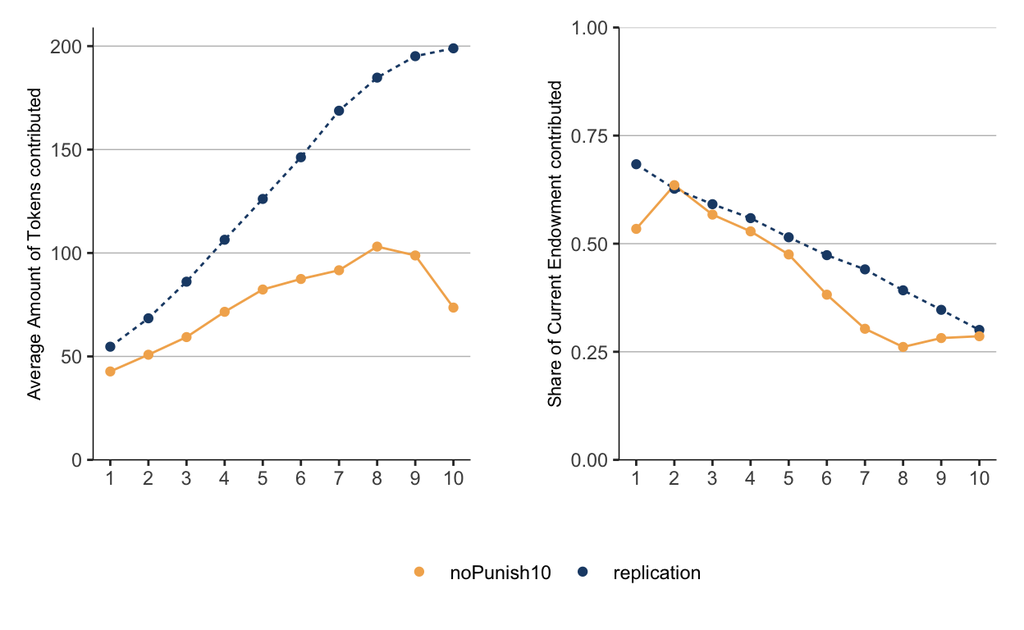

Figure 1: The average amount of tokens contributed over time in treatments.

```r
SHARE <- main[,
            lapply(.SD, mean, na.rm = TRUE),
            by = c("round", "treatment"),
            .SDcols = "share"]

upperLimit <- 1

p2 <- ggplot(data = SHARE,
             aes(x = round, y = share, fill = treatment, color = treatment, lty = treatment)) +
  layout +
  theme(legend.position="bottom") +
  geom_line(show.legend=FALSE) +
  geom_point() +
  scale_x_continuous(name="",  breaks = 1:15) +
  scale_y_continuous(limits = c(0, upperLimit), expand = c(0, 0)) +
  labs(y = "Share of Current Endowment contributed") +
  scale_color_manual(values = colors)

p1 + p2 + plot_layout(guides = "collect") & theme(legend.position = "bottom")
```

```r
rm(list = c("SHARE", "p1", "p2"))
```

```r
if(knitr::is_html_output()){
  type <- "html"
} else {
  type = "latex"
}

replication <- main[treatment == "replication" & round == 10, stock]
GMTV    <- main[treatment == "noPunish10" & round == 10, stock]


rows <- sapply(X = list(replication, GMTV), FUN = NROW) %>% max()
temp <- data.frame(replication = c(replication, rep(NA, rows - NROW(replication))),
                   GMTV = c(GMTV, rep(NA, rows - NROW(GMTV))))

stargazer(temp,
          summary.stat = c("mean", "median","sd", "max", "min", "n"),
          type = type,
          flip = TRUE,
          header=FALSE)
```

| Statistic | replication | GMTV |
| --- | --- | --- |
| Mean | 764.333 | 478.087 |
| Median | 774.5 | 304.000 |
| St. Dev. | 41.790 | 393.575 |
| Max | 833 | 1,792.000 |
| Min | 646 | 161.000 |
| N | 30 | 23 |

```r
rs1 <- wilcox.test(replication,
                   GMTV,
                   exact = FALSE)$p.value %>%
  round(digits = 4) %>%
  formatC(format = "f",
          digits = 4)
```

The rank sum test yields a p-Value of 0.0001 for the mean `stock` a.k.a *Wealth* during the last period of the game.

```r
# create subsets
main_all  <- main[round == 10]
main_poor <- main[round == 10 & rich == FALSE]
main_rich <- main[round == 10 & rich == TRUE]

# create table
if(knitr::is_html_output()){
  type <- "html"
} else {
  type = "latex"
}

stargazer(lm(formula = stock ~ treatment, data = main_all),
          lm(formula = stock ~ treatment, data = main_poor),
          lm(formula = stock ~ treatment, data = main_rich),

          column.labels = c("All", "Below median", "Above median"),
          model.numbers = FALSE,
          dep.var.labels = "Wealth",
          header=FALSE,
          covariate.labels = c("Replication"),

          type = type, digits = 2, omit.stat = c("adj.rsq", "f"), df = FALSE
          )
```

|  | *Dependent variable:* |  |  |
| --- | --- | --- | --- |
|  | Wealth |  |  |
|  | All | Below median | Above median |
| Replication | 286.25*** | 499.03*** | 63.93 |
|  | (72.17) | (15.61) | (115.74) |
| Constant | 478.09*** | 234.70*** | 731.00*** |
|  | (54.30) | (12.09) | (87.91) |
| Observations | 53 | 25 | 26 |
| R<sup>2</sup> | 0.24 | 0.98 | 0.01 |
| Residual Std. Error | 260.41 | 38.24 | 291.56 |
| *Note:* | p<0.1; p<0.05; p<0.01 |  |  |

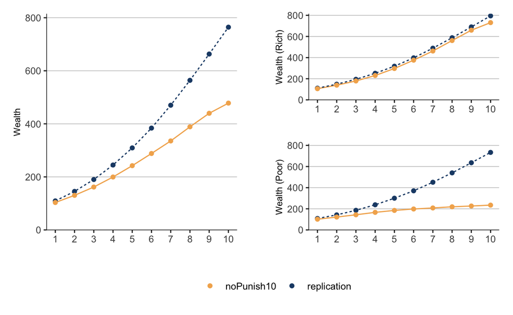

Figure 2: Average wealth over time across treatments.

```r
STOCK <- main[,
              lapply(.SD, mean, na.rm = TRUE),
              by = c("round", "treatment"),
              .SDcols = "stock"]

STOCKr <- main[rich == TRUE,
               lapply(.SD, mean, na.rm = TRUE),
               by = c("round", "treatment"),
               .SDcols = "stock"]

STOCKp <- main[rich == FALSE,
               lapply(.SD, mean, na.rm = TRUE),
               by = c("round", "treatment"),
               .SDcols = "stock"]

upperLimit <- STOCKr$stock %>% max() %>% round() + 20

p1 <- ggplot(data = STOCK,
       aes(x = round, y = stock, fill = treatment, color = treatment, lty = treatment)) +
          layout +
          theme(legend.position="bottom") +
          # geom_vline(xintercept = 10, alpha = 0.66) +
          geom_line(show.legend=FALSE) +
          geom_point() +
          scale_x_continuous(name="",  breaks = 1:10) +
          scale_y_continuous(limits = c(0, upperLimit), expand = c(0, 0)) +
          labs(y = "Wealth") +
          scale_color_manual(values = colors) +
          theme(plot.margin = margin(0.25,1,0.25,0.25, "cm"))

p2 <- ggplot(data = STOCKr,
       aes(x = round, y = stock, fill = treatment, color = treatment, lty = treatment)) +
          layout +
          theme(legend.position="bottom") +
          # geom_vline(xintercept = 10, alpha = 0.66) +
          geom_line(show.legend=FALSE) +
          geom_point() +
          scale_x_continuous(name="",  breaks = 1:10) +
          scale_y_continuous(limits = c(0, upperLimit), expand = c(0, 0)) +
          labs(y = "Wealth (Rich)") +
          scale_color_manual(values = colors)

p3 <- ggplot(data = STOCKp,
       aes(x = round, y = stock, fill = treatment, color = treatment, lty = treatment)) +
          layout +
          theme(legend.position="bottom") +
          # geom_vline(xintercept = 10, alpha = 0.66) +
          geom_line(show.legend=FALSE) +
          geom_point() +
          scale_x_continuous(name="",  breaks = 1:10) +
          scale_y_continuous(limits = c(0, upperLimit), expand = c(0, 0)) +
          labs(y = "Wealth (Poor)") +
          scale_color_manual(values = colors)

(p1 | (p2 / p3)) + plot_layout(guides = "collect") & theme(legend.position = "bottom")
```

```r
rm(list = c("STOCK", "STOCKr", "STOCKp", "p1", "p2", "p3"))
```

## Inequality

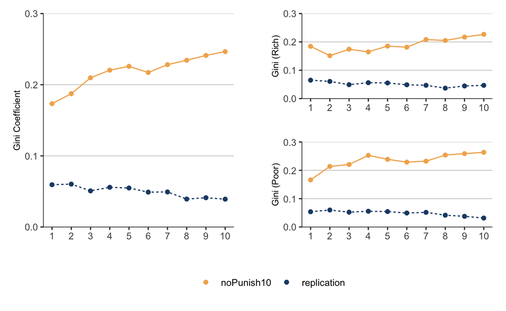

Figure 3: Average Gini coefficient over time across treatments.

```r
GINI <- main[,
             lapply(.SD, mean, na.rm = TRUE),
             by = c("round", "treatment"),
             .SDcols = "gini"]

GINIr <- main[rich == TRUE,
              lapply(.SD, mean, na.rm = TRUE),
              by = c("round", "treatment"),
              .SDcols = "gini"]

GINIp <- main[rich == FALSE,
              lapply(.SD, mean, na.rm = TRUE),
              by = c("round", "treatment"),
              .SDcols = "gini"]

upperLimit <- GINI$gini %>% max() %>% round(digits = 1) + 0.10

p1 <- ggplot(data = GINI,
       aes(x = round, y = gini, fill = treatment, color = treatment, lty = treatment)) +
          layout +
          theme(legend.position="bottom") +
          # geom_vline(xintercept = 10, alpha = 0.66) +
          geom_line(show.legend=FALSE) +
          geom_point() +
          scale_x_continuous(name="",  breaks = 1:10) +
          scale_y_continuous(limits = c(0, upperLimit), expand = c(0, 0)) +
          labs(y = "Gini Coefficient") +
          scale_color_manual(values = colors) +
          theme(plot.margin = margin(0.25,1,0.25,0.25, "cm"))

p2 <- ggplot(data = GINIr,
       aes(x = round, y = gini, fill = treatment, color = treatment, lty = treatment)) +
          layout +
          theme(legend.position="bottom") +
          # geom_vline(xintercept = 10, alpha = 0.66) +
          geom_line(show.legend=FALSE) +
          geom_point() +
          scale_x_continuous(name="",  breaks = 1:10) +
          scale_y_continuous(limits = c(0, upperLimit), expand = c(0, 0)) +
          labs(y = "Gini (Rich)") +
          scale_color_manual(values = colors)

p3 <- ggplot(data = GINIp,
       aes(x = round, y = gini, fill = treatment, color = treatment, lty = treatment)) +
          layout +
          theme(legend.position="bottom") +
          # geom_vline(xintercept = 10, alpha = 0.66) +
          geom_line(show.legend=FALSE) +
          geom_point() +
          scale_x_continuous(name="",  breaks = 1:10) +
          scale_y_continuous(limits = c(0, upperLimit), expand = c(0, 0)) +
          labs(y = "Gini (Poor)") +
          scale_color_manual(values = colors)

(p1 | (p2 / p3)) + plot_layout(guides = "collect") & theme(legend.position = "bottom")
```

```r
rm(list = c("GINI", "GINIp", "GINIr", "p1", "p2", "p3"))
```

```r
# create subsets
main_all  <- main[round == 10]
main_poor <- main[round == 10 & rich == FALSE]
main_rich <- main[round == 10 & rich == TRUE]

# create table
if(knitr::is_html_output()){
  type <- "html"
} else {
  type = "latex"
}

stargazer(lm(formula = gini ~ treatment, data = main_all),
          lm(formula = gini ~ treatment, data = main_poor),
          lm(formula = gini ~ treatment, data = main_rich),

          column.labels = c("All", "Below median", "Above median"),
          model.numbers = FALSE,
          dep.var.labels = "Gini",
          header=FALSE,
          covariate.labels = c("Replication"),

          type = type, digits = 2, omit.stat = c("adj.rsq", "f"), df = FALSE
          )
```

|  | *Dependent variable:* |  |  |
| --- | --- | --- | --- |
|  | Gini |  |  |
|  | All | Below median | Above median |
| Replication | -0.21*** | -0.23*** | -0.18*** |
|  | (0.02) | (0.04) | (0.03) |
| Constant | 0.25*** | 0.26*** | 0.23*** |
|  | (0.02) | (0.03) | (0.02) |
| Observations | 53 | 25 | 26 |
| R<sup>2</sup> | 0.59 | 0.61 | 0.56 |
| Residual Std. Error | 0.09 | 0.10 | 0.08 |
| *Note:* | p<0.1; p<0.05; p<0.01 |  |  |

```r
if(knitr::is_html_output()){
  type <- "html"
} else {
  type = "latex"
}

replication <- main[treatment == "replication" & round == 10, gini]
GMTV    <- main[treatment == "noPunish10" & round == 10, gini]


rows <- sapply(X = list(replication, GMTV), FUN = NROW) %>% max()
temp <- data.frame(replication = c(replication, rep(NA, rows - NROW(replication))),
                   GMTV = c(GMTV, rep(NA, rows - NROW(GMTV))))

stargazer(temp,
          summary.stat = c("mean", "median","sd", "max", "min", "n"),
          type = type,
          flip = TRUE,
          header=FALSE)
```

| Statistic | replication | GMTV |
| --- | --- | --- |
| Mean | 0.039 | 0.246 |
| Median | 0.035 | 0.245 |
| St. Dev. | 0.016 | 0.131 |
| Max | 0.074 | 0.479 |
| Min | 0.012 | 0.044 |
| N | 30 | 23 |

```r
rs2 <- wilcox.test(replication,
                   GMTV,
                   exact = FALSE)$p.value %>%
  round(digits = 4) %>%
  formatC(format = "f",
          digits = 4)
```

The rank sum test yields a p-Value of 0.0000 for the mean `gini` during the last period of the game.

## Sample Properties

```r
covariates <- data.table::merge.data.table(x  = covs,
                                           y  = main[round == 10, .(groupID, stock, gini)],
                                           by = c("groupID"),
                                           allow.cartesian = TRUE)

covariates[,
           gender := gender %>% as.numeric()]
```

In addition to the summary statistics a regression table for each covariate as a dependent variable is needed. The independent variable will then be the data source (i.e. GMTV vs replication).

```r
# create table
if(knitr::is_html_output()){
  type <- "html"
} else {
  type = "latex"
}

temp <- covariates[treatment == "replication",
                   .(gender, age, switching_row, education, donation, pq01, pq02, pq03, pq04,
                     pq05, pq06, pq07, pq08, pq09, pq10, pq11, pq12, pq13, pq14)]
stargazer(temp, type = type, flip = FALSE)
```

| Statistic | N | Mean | St. Dev. | Min | Pctl(25) | Pctl(75) | Max |
| --- | --- | --- | --- | --- | --- | --- | --- |
| gender | 120 | 0.250 | 0.435 | 0 | 0 | 0.2 | 1 |
| age | 120 | 44.125 | 14.817 | 18 | 31.8 | 59 | 66 |
| switching_row | 120 | 6.525 | 0.501 | 6 | 6 | 7 | 7 |
| education | 120 | 3.858 | 2.642 | 0 | 2 | 6 | 8 |
| donation | 120 | 1.992 | 1.131 | 0.000 | 1.150 | 2.938 | 4.200 |
| pq01 | 120 | 2.683 | 1.996 | 0 | 1 | 4 | 6 |
| pq02 | 120 | 3.317 | 1.801 | 0 | 2 | 5 | 6 |
| pq03 | 120 | 3.133 | 2.000 | 0 | 1 | 5 | 6 |
| pq04 | 120 | 2.883 | 1.902 | 0 | 1 | 4.2 | 6 |
| pq05 | 120 | 3.033 | 2.021 | 0 | 1 | 5 | 6 |
| pq06 | 120 | 2.667 | 2.039 | 0 | 1 | 5 | 6 |
| pq07 | 120 | 3.100 | 1.968 | 0 | 2 | 5 | 6 |
| pq08 | 120 | 2.950 | 2.033 | 0 | 1 | 5 | 6 |
| pq09 | 120 | 2.917 | 2.064 | 0 | 1 | 5 | 6 |
| pq10 | 120 | 3.100 | 1.964 | 0 | 1.8 | 5 | 6 |
| pq11 | 120 | 2.967 | 2.086 | 0 | 1 | 5 | 6 |
| pq12 | 120 | 2.917 | 1.977 | 0 | 1 | 5 | 6 |
| pq13 | 120 | 3.375 | 1.949 | 0 | 2 | 5 | 6 |
| pq14 | 120 | 3.075 | 2.063 | 0 | 1 | 5 | 6 |

```r
# create table
if(knitr::is_html_output()){
  type <- "html"
} else {
  type = "latex"
}

olsStock1 <- lm(formula = stock ~ gender + age + switching_row + pq01 + pq02 + pq03 + pq04 +
                  pq05 + pq06 + pq07 +pq08 + pq09 + pq10 + pq11 + pq12 + pq13 + pq14,
                data = covariates[treatment == "replication"])
olsStock2  <- lm(formula = stock ~ gender + age + switching_row,
                data = covariates[treatment == "replication"])
olsGINI1  <- lm(formula = gini ~ gender + age + switching_row + pq01 + pq02 + pq03 + pq04 +
                  pq05 + pq06 + pq07 + pq08 + pq09 + pq10 + pq11 + pq12 + pq13 + pq14,
                data = covariates[treatment == "replication"])
olsGINI2  <- lm(formula = gini ~ gender + age + switching_row,
                data = covariates[treatment == "replication"])

stargazer(olsStock1, olsStock2,
          olsGINI1, olsGINI2,

          se = list(coef(summary(olsStock1, cluster = c("groupID")))[, 2],
                    coef(summary(olsStock2, cluster = c("groupID")))[, 2],
                    coef(summary(olsGINI1,  cluster = c("groupID")))[, 2],
                    coef(summary(olsGINI2,  cluster = c("groupID")))[, 2]),

          column.labels   = c("Wealth", "Gini"),
          dep.var.labels.include = FALSE,
          column.separate = c(2, 2),
          model.numbers = FALSE,
          header=FALSE,
          covariate.labels = c("female", "age", "risk",
                               "I am a quick thinker",
                               "I get easily offended",
                               "very satisfied",
                               "very dependent",
                               "generally happy",
                               "work important",
                               "family important",
                               "friends important",
                               "religion important",
                               "politics important",
                               "most people trusted",
                               "hard work better",
                               "government responsible",
                               "incomes equal"),
          notes = "Robust standard errors in parentheses, clustered by group ID.",

          type = type, digits = 2, omit.stat = c("adj.rsq", "f"), df = FALSE
          )
```

|  | *Dependent variable:* |  |  |  |
| --- | --- | --- | --- | --- |
|  | Wealth |  | Gini |  |
| female | -9.36 | -10.53 | 0.001 | 0.001 |
|  | (8.99) | (8.62) | (0.004) | (0.003) |
| age | -0.66** | -0.51** | -0.0000 | -0.0000 |
|  | (0.28) | (0.25) | (0.0001) | (0.0001) |
| risk | -7.43 | -9.54 | -0.001 | -0.001 |
|  | (8.01) | (7.43) | (0.003) | (0.003) |
| I am a quick thinker | 1.36 |  | 0.001 |  |
|  | (2.06) |  | (0.001) |  |
| I get easily offended | 1.08 |  | -0.0001 |  |
|  | (2.18) |  | (0.001) |  |
| very satisfied | 0.72 |  | 0.001 |  |
|  | (1.97) |  | (0.001) |  |
| very dependent | -4.86** |  | 0.0005 |  |
|  | (2.03) |  | (0.001) |  |
| generally happy | 0.64 |  | 0.0004 |  |
|  | (1.88) |  | (0.001) |  |
| work important | 3.65* |  | 0.002** |  |
|  | (1.95) |  | (0.001) |  |
| family important | 2.57 |  | 0.0000 |  |
|  | (2.06) |  | (0.001) |  |
| friends important | -1.56 |  | -0.001 |  |
|  | (1.97) |  | (0.001) |  |
| religion important | -2.73 |  | -0.001 |  |
|  | (1.85) |  | (0.001) |  |
| politics important | -3.62* |  | -0.0001 |  |
|  | (2.03) |  | (0.001) |  |
| most people trusted | 1.93 |  | 0.0004 |  |
|  | (1.90) |  | (0.001) |  |
| hard work better | 1.71 |  | -0.0002 |  |
|  | (1.99) |  | (0.001) |  |
| government responsible | -1.03 |  | 0.0000 |  |
|  | (2.06) |  | (0.001) |  |
| incomes equal | -0.93 |  | 0.001 |  |
|  | (1.92) |  | (0.001) |  |
| Constant | 848.76*** | 851.75*** | 0.03 | 0.04** |
|  | (58.45) | (49.57) | (0.02) | (0.02) |
| Observations | 120 | 120 | 120 | 120 |
| R<sup>2</sup> | 0.19 | 0.06 | 0.10 | 0.002 |
| Residual Std. Error | 40.03 | 40.58 | 0.02 | 0.02 |
| *Note:* | p<0.1; p<0.05; p<0.01 |  |  |  |
|  | Robust standard errors in parentheses, clustered by group ID. |  |  |  |

Chen, Daniel L., Martin Schonger, and Chris Wickens. 2016. “oTree-an Open-Source Platform for Laboratory, Online, and Field Experiments.” *Journal of Behavioral and Experimental Finance* 9: 88–97. https://doi.org/10.1016/j.jbef.2015.12.001.

Gächter, Simon, Friederike Mengel, Elias Tsakas, and Alexander Vostroknutov. 2017. “Growth and Inequality in Public Good Provision.” *Journal of Public Economics* 150: 1–13. https://doi.org/10.1016/j.jpubeco.2017.03.002.